# JHU Coursera Practical Machine learning course project

Pablo O Rodriguez

## Introduction

This documents summarizes the analysis I performed following the JHU Coursera Practical Machine learning course project instructions. The task was to develop a machine learning model to predict the class of exercise quality during an experiment. The goal of the experiment was to assess whether mistakes could be detected in weight-lifting exercises by using activity recognition techniques. Authors recorded users performing the same activity correctly and with a set of common mistakes with wearable sensors. Detailed information can be found [here](http://groupware.les.inf.puc-rio.br/public/papers/2013.Velloso.QAR-WLE.pdf).  
Six articipants were asked to perform one set of 10 repetitions of the Unilateral Dumbbell Biceps Curl in five different fashions (classes):

-A: exactly according to the specification  
-B: throwing the elbows to the front  
-C: lifting the dumbbell only halfway  
-D: lowering the dumbbell only halfway  
-E: throwing the hips to the front

Features were: Euler angles (roll, pitch and yaw, see [wikipedia](https://en.wikipedia.org/wiki/Euler_angles)), as well as the raw accelerometer, gyroscope and magnetometer readings from wearable sensors in the participans’ glove, armband, lumbar belt and dumbbell. [Read more](http://groupware.les.inf.puc-rio.br/har#ixzz48lsA1uQ3)

## Data processing

Data was downloaded to the working directory, loaded, and cleaned (in the training set there were several variables with a large number of missing values. This were calculated features by the authors which I will not use). The first 7 variables in the data.frame contain useless informations for the prediction model, so I excluded them.

```r
##Load required libraries
suppressPackageStartupMessages({library (caret); library (ggplot2)})

################################Getting data####
##First download training and test data files if they are not in the
##working directory

if(!file.exists("dataTraining.txt")){
  download.file("https://d396qusza40orc.cloudfront.net/predmachlearn/pml-training.csv",
                "dataTraining.txt")
}

if(!file.exists("dataTest.txt")){
  download.file("https://d396qusza40orc.cloudfront.net/predmachlearn/pml-testing.csv",
                "dataTest.txt")
}

##Load training and test data (the latter to be used for the 2nd part of the course project assignment)

dataTraining<-read.csv("dataTraining.txt",header = TRUE,stringsAsFactors = FALSE,na.strings = c("","NA"))
dataTest<-read.csv("dataTest.txt", header = TRUE, stringsAsFactors = FALSE,na.strings = c("","NA"))


########################Cleaning data##############
##Detecting variables with rate of missing data and selecting variables of data.frames
naVar<-apply(dataTraining,2, function (x) mean(is.na(x)))

dataTraining<-dataTraining[,naVar<0.5]
dataTest<-dataTest[,naVar<0.5]


##Subsetting interesting variables

dataTraining<-dataTraining[,8:ncol(dataTraining)]
dataTest<-dataTest[,8:ncol(dataTest)]
```

The resulting dataset has 19622 rows and 53 columns. The outcome is *classe* as explained above and there are 52 potential predictors. This dataset was split in 2 (training and test set, ratio 70:30) to train and set the prediction model.

```r
##########################Spliting data in training and test sets###############
##Split dataTraining in 2 training and test set for out of sample error estimation

trainingSubset<-createDataPartition(y = dataTraining$classe,p = .7,list = FALSE)

training<-dataTraining[trainingSubset,]
test<-dataTraining[-trainingSubset,]
```

To reduce the dimensions of the covariates matrix, I first eliminated highly correlated variables using the caret::findCorrelation function (see the [caret tutorial](http://topepo.github.io/caret/preprocess.html)).

```r
##eliminates highly correlated variables (r>.9)
corMatrix<-cor(training[,-53])
highCor<-findCorrelation(corMatrix,cutoff = .9)

training<-training[,-highCor]
test<-test[,-highCor]
```

There were 0 predictors with near zero variance to exclude.

## Models training

This is a classification problem, so I decided to evaluate the performance of 4 different approaches on the training data set: linear discrimination analysis (LDA), quadratic discrimination analysis (QDA), boosting trees (GBM: gradient boosting machine) and random forest (RF). In each case I used 10 k-fold cross validation for accuracy and out of the sample error stimation.

```r
########################################### Modeling##################
###Modelling with caret::train function with 10 k-fold cross validation
tc<-trainControl(method = "cv",number = 10)

##LDA model
set.seed(1234)
modelLDA<-train(form = classe ~ .,
                data = training,
                trControl=tc,
                method="lda",
                verbose=FALSE)

##QDA model
set.seed(1234)
modelQDA<-train(form = classe ~ .,
                data = training,
                trControl=tc,
                method="qda",
                verbose=FALSE)


##Boosted tree model (gbm, gradient boosting machine)
set.seed(1234)
modelBoost<-train(form = classe ~ .,
                  data = training,
                  trControl=tc,
                  method="gbm",
                  verbose=FALSE)
##Random forest
set.seed(1234)
modelRF<-train(form = classe ~ .,
                  data = training,
                  trControl=tc,
                  method="rf",
                  verbose=FALSE)
```

**Expected bias and variance with k-fold cross validation**

The plot shows the accuracy and kappa value from all the models:

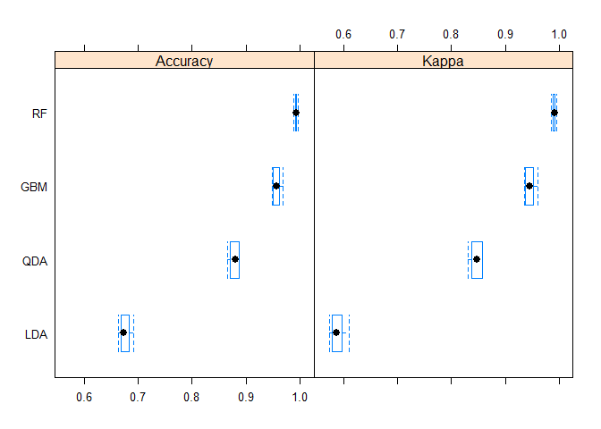

```r
######################Model selection####################
##Choose best model comparing metrics on cv
resamps <- resamples(list(LDA = modelLDA,
                          QDA = modelQDA,
                          GBM = modelBoost,
                          RF= modelRF))

bwplot(resamps)
```

RF appears as the most accurate model with a low out of the sample error stimation in the cross validation. Thus I use it to evaluate with the test set.

## Testing the RF model with test set (from the initial split)

This is the result of the caret::confusionMatrix function of the RF model on the test dataset.

```r
#####################testing RF model on test set##############
testPrediction<-predict(modelRF,test)

confusionMatrix(testPrediction,test$classe)
```

```
## Confusion Matrix and Statistics
##
##           Reference
## Prediction    A    B    C    D    E
##          A 1668    6    0    0    0
##          B    4 1133    8    0    0
##          C    0    0 1013   14    2
##          D    0    0    5  950    3
##          E    2    0    0    0 1077
##
## Overall Statistics
##
##                Accuracy : 0.9925
##                  95% CI : (0.99, 0.9946)
##     No Information Rate : 0.2845
##     P-Value [Acc > NIR] : < 2.2e-16
##
##                   Kappa : 0.9905
##  Mcnemar's Test P-Value : NA
##
## Statistics by Class:
##
##                      Class: A Class: B Class: C Class: D Class: E
## Sensitivity            0.9964   0.9947   0.9873   0.9855   0.9954
## Specificity            0.9986   0.9975   0.9967   0.9984   0.9996
## Pos Pred Value         0.9964   0.9895   0.9845   0.9916   0.9981
## Neg Pred Value         0.9986   0.9987   0.9973   0.9972   0.9990
## Prevalence             0.2845   0.1935   0.1743   0.1638   0.1839
## Detection Rate         0.2834   0.1925   0.1721   0.1614   0.1830
## Detection Prevalence   0.2845   0.1946   0.1749   0.1628   0.1833
## Balanced Accuracy      0.9975   0.9961   0.9920   0.9919   0.9975
```

## Predictions on dataTest set

I finally used predict function with the RF model on the dataTest as the assignment in the course project.

```r
predict(modelRF, dataTest)
```

```
##  [1] B A B A A E D B A A B C B A E E A B B B
## Levels: A B C D E
```

word count: 918